# Basic Stats and Visualization (From Texas A&M University OSOS Workshop 2020)

## Looking at interaction data

but what about an interaction effect of something like how many cylinders it has? if the car is heavier because of the engine and not something else, maybe there’s an effect?

```r
carfit3<-lm(mpg~wt+cyl+wt*cyl, data=mtcars)
summary(carfit3)
```

```
##
## Call:
## lm(formula = mpg ~ wt + cyl + wt * cyl, data = mtcars)
##
## Residuals:
##     Min      1Q  Median      3Q     Max
## -4.2288 -1.3495 -0.5042  1.4647  5.2344
##
## Coefficients:
##             Estimate Std. Error t value Pr(>|t|)
## (Intercept)  54.3068     6.1275   8.863 1.29e-09 ***
## wt           -8.6556     2.3201  -3.731 0.000861 ***
## cyl          -3.8032     1.0050  -3.784 0.000747 ***
## wt:cyl        0.8084     0.3273   2.470 0.019882 *
## ---
## Signif. codes:  0 '***' 0.001 '**' 0.01 '*' 0.05 '.' 0.1 ' ' 1
##
## Residual standard error: 2.368 on 28 degrees of freedom
## Multiple R-squared:  0.8606, Adjusted R-squared:  0.8457
## F-statistic: 57.62 on 3 and 28 DF,  p-value: 4.231e-12
```

we see that weight is significant to the model, as is cylinder, BUT we see a significant interaction between cylinder and weight

what’s going on here? We know that as weight goes up, the mpg goes down

[figure not shown]

```r
plot(mpg~cyl, data=mtcars)
```

but we know as the cylinders go up, the mpg goes down too

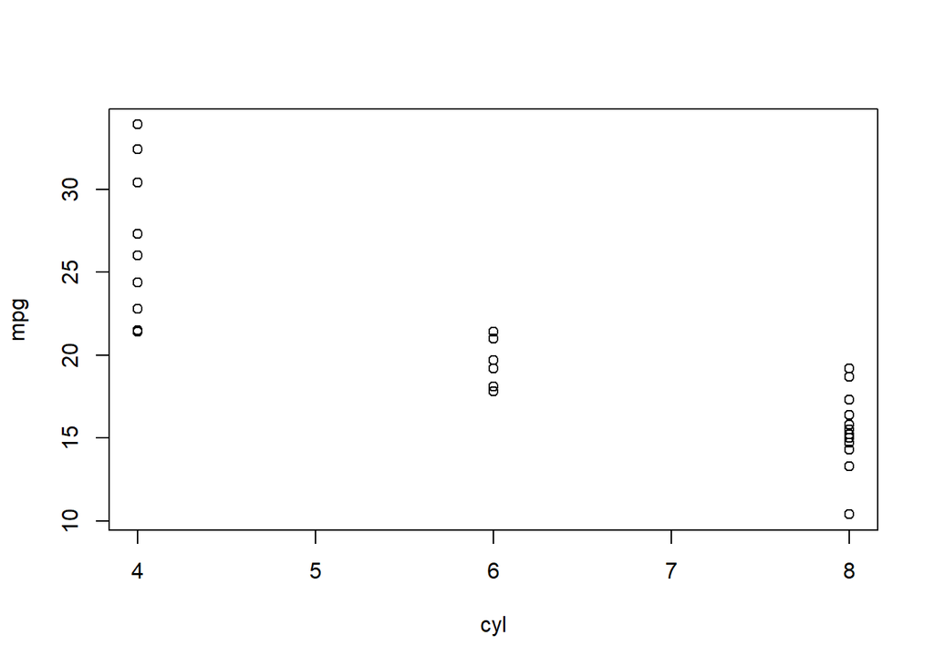

```r
plot(mpg~cyl, data=mtcars)
```

what happens to wt as cylinders go up?

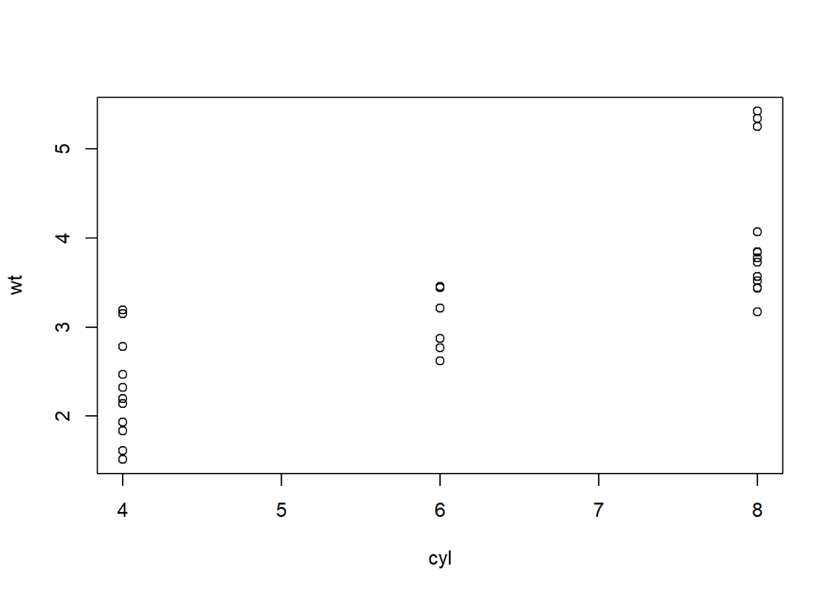

```r
plot(wt~cyl, data=mtcars)
```

## ggplot for scatterplots

ggplot is pretty easy to set up here too for scatter plots

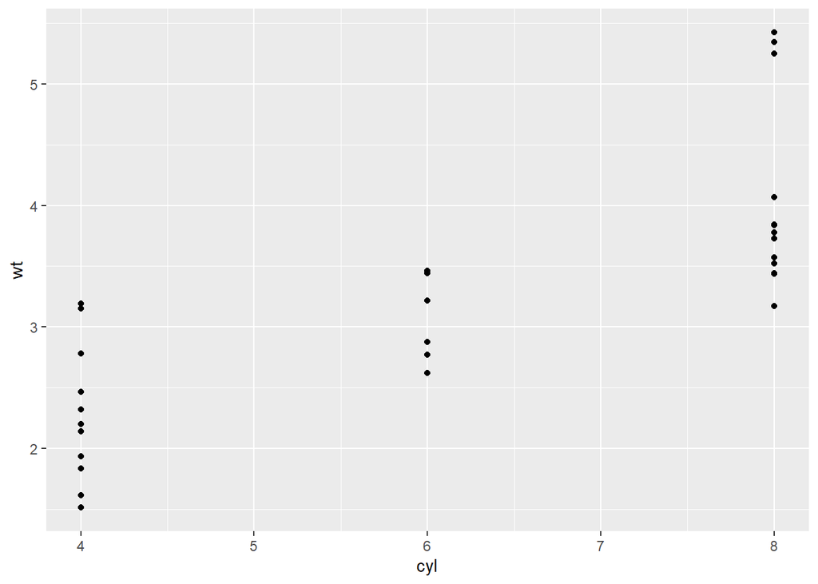

```r
p4<-ggplot(data=mtcars, aes(x=cyl, y=wt))+geom_point()
p4
```

if we look at our summary again, we can see that the estimate for the interaction is positive, whereas the estimates for the wt and cyl independently are negative. This means, while wt and cyl are negatively impacting mpg, as cylinder increases, the effect of wt on mpg decreases. There is an interaction of these variables

and if we compare the simpler wt+cyl model to our more complex model, the more complex model is significantly better

```r
anova(carfit2, carfit3)
```

```
## Analysis of Variance Table
##
## Model 1: mpg ~ wt + cyl
## Model 2: mpg ~ wt + cyl + wt * cyl
##   Res.Df    RSS Df Sum of Sq      F  Pr(>F)
## 1     29 191.17
## 2     28 156.98  1    34.196 6.0995 0.01988 *
## ---
## Signif. codes:  0 '***' 0.001 '**' 0.01 '*' 0.05 '.' 0.1 ' ' 1
```

you can plot these with cool graphs, but that is something you can do easily outside of base R (ggplot2, etc)

## What about categorical data? Using marginal frequency tables

So What if we have categorical/character data? Maybe something from a survey or phenotypes from genetic crosses? What if we want to know if there is a more common combination of hair and eye color let’s load the available dataset in R called HairEyeColor

```r
data("HairEyeColor")
```

let’s look at it

```r
str(HairEyeColor)
```

```
##  'table' num [1:4, 1:4, 1:2] 32 53 10 3 11 50 10 30 10 25 ...
##  - attr(*, "dimnames")=List of 3
##   ..$ Hair: chr [1:4] "Black" "Brown" "Red" "Blond"
##   ..$ Eye : chr [1:4] "Brown" "Blue" "Hazel" "Green"
##   ..$ Sex : chr [1:2] "Male" "Female"
```

```r
HairEyeColor
```

```
## , , Sex = Male
##
##        Eye
## Hair    Brown Blue Hazel Green
##   Black    32   11    10     3
##   Brown    53   50    25    15
##   Red      10   10     7     7
##   Blond     3   30     5     8
##
## , , Sex = Female
##
##        Eye
## Hair    Brown Blue Hazel Green
##   Black    36    9     5     2
##   Brown    66   34    29    14
##   Red      16    7     7     7
##   Blond     4   64     5     8
```

it’s in kind of a weird format, and for our question, we are not worried about sex we can use the function margin.table to give us all of our output for a marginal frequency table

```r
HairEyeNew<-margin.table(HairEyeColor, margin=c(1,2))
```

let’s see what it looks like

```r
HairEyeNew
```

```
##        Eye
## Hair    Brown Blue Hazel Green
##   Black    68   20    15     5
##   Brown   119   84    54    29
##   Red      26   17    14    14
##   Blond     7   94    10    16
```

we can see it is all in a usable table now, but raw numbers are not what we are interested in

## Chi-square test

what kind of test would we use to see if something is more or less than expected? chi-square is common we can use this function with what we saved as a marginal frequency table

```r
chisq.test(HairEyeNew)
```

```
##
##  Pearson's Chi-squared test
##
## data:  HairEyeNew
## X-squared = 138.29, df = 9, p-value < 2.2e-16
```

we see something is significant, but we want to see what frequencies we have. in order to calculate frequency, we need to divide what we have by the totals

```r
HairEyeNew/sum(HairEyeNew)
```

```
##        Eye
## Hair          Brown        Blue       Hazel       Green
##   Black 0.114864865 0.033783784 0.025337838 0.008445946
##   Brown 0.201013514 0.141891892 0.091216216 0.048986486
##   Red   0.043918919 0.028716216 0.023648649 0.023648649
##   Blond 0.011824324 0.158783784 0.016891892 0.027027027
```